# Pokémon dataset

Tipologia i cicle de vida de les dades - Pràctica 2

Joel Santacana i Xavier Paricio

21 Maig 2020

# 1 Pregunta

## 1.1 Descripció del dataset

Aquest dataset conté la informació de tots els 800 pokemons pertanyents a les 7 generacions existents. La informació continguda en aquest dataset inclou estadístiques base, rendiment contra altres tipus, alçada, pes, classificació, experiència, etc. Aquest dataset ha estat descarregat del lloc web www.kaggle.com i l’autor l’ha creat a través d’un procés webscraping the www.serebii.net.

```
## 'data.frame':    801 obs. of  41 variables:
##  $ abilities        : Factor w/ 482 levels "['Adaptability', 'Download', 'Analytic']",..: 244 244 244 22 22 22 453 453 453 348 ...
##  $ against_bug      : num  1 1 1 0.5 0.5 0.25 1 1 1 1 ...
##  $ against_dark     : num  1 1 1 1 1 1 1 1 1 1 ...
##  $ against_dragon   : num  1 1 1 1 1 1 1 1 1 1 ...
##  $ against_electric : num  0.5 0.5 0.5 1 1 2 2 2 2 1 ...
##  $ against_fairy    : num  0.5 0.5 0.5 0.5 0.5 0.5 1 1 1 1 ...
##  $ against_fight    : num  0.5 0.5 0.5 1 1 0.5 1 1 1 0.5 ...
##  $ against_fire     : num  2 2 2 0.5 0.5 0.5 0.5 0.5 0.5 2 ...
##  $ against_flying   : num  2 2 2 1 1 1 1 1 1 2 ...
##  $ against_ghost    : num  1 1 1 1 1 1 1 1 1 1 ...
##  $ against_grass    : num  0.25 0.25 0.25 0.5 0.5 0.25 2 2 2 0.5 ...
##  $ against_ground   : num  1 1 1 2 2 0 1 1 1 0.5 ...
##  $ against_ice      : num  2 2 2 0.5 0.5 1 0.5 0.5 0.5 1 ...
##  $ against_normal   : num  1 1 1 1 1 1 1 1 1 1 ...
```

[output cut: 27 more lines]

Veiem que el dataset està format per **801 observacions i 41 columnes**. A continuació, es mostra una descripció dels atributs:

**-Name**: Nom en anglès del Pokémon

**-japanese_name**: Nom en japonès del Pokémon

**-percentage_male**: Percentatge de les espècies que són mascle. En blanc si no tenen gènere.

**pokedex_number**: Número de pokémon a la pokédex.

**-type1**: Tipus principal del pokémon

**-type2**: Tipus secundari del pokémon

**-classication**: Classificació del Pokémon segons la Pokédex de l’edició Sol i lluna

**-height_m**: Alçada del Pokémon en metres

**-weight_kg**: Pes del Pokémon en kg

**-capture_rate**: Rati de captura del pokémon

**-baseeggsteps**: Nombre de passos requerits perquè l’ou s’obri

**-abilities**: Llistat d’habilitats que el Pokémon pot tenir

**-experience_growth**: Punts d’experiència totals del Pokémon

**-base_happiness**: Punts base de felicitat del pokémon

**-against_?**: 18 variables que descriuen el dany rebut contra un tipus particular d’atac

**-base_total**: Suma total dels stats base

**-hp**: Punts base HP del pokémon

**-attack**: Punts base d’atac del Pokémon

**-defense**: Punts base de defensa del Pokémon

**-attack**: Punts base d’atac del Pokémon

**-sp_attack**: Punts base d’atac especial del Pokémon

**-sp_defense**: Punts base de defensa especial del Pokémon

**-speed**: Punts base de velocitat del Pokémon

**-generation**: Generació de Pokémon en la que va ser introduït

**-is_legendary**: Denota si un Pokémon és llegendari. 1 si és llegndari, 0 si no ho és.

## 1.2 Perquè és important el dataset

Pokémon és una saga creada per Nintendo l’any 1995. Actualment Pokémon és la franquícia digital més valorada arreu del món amb un valor de 92.121 B$. Actualment, continua produint noves edicions i degut al impacte econòmic i social que genera aquesta franquícia, aquest anàlisis seria útil per tots aquells jugadors que vulguin millorar el seu equip Pokémon i ser més competitius.

## 1.3 Preguntes o curiositats que es pretenen respondre

- És possible construir un classificador per identificador els pokemons llegendaris?
- Quina correlació existeix entre l’alçada i el pes d’un pokemon amb les seves estadístiques base?
- Quins Pokémons tenen els stats més alts?
- Quina efectivitat hi ha entre tipus de Pokémons?
- Quins pokémons són més feliços?

# 2 Pregunta

## 2.1 Integració

El dataset amb el que treballarem no necessita cap tipus d’integració de dades ja que es tracta d’un únic dataset. Així doncs, aquest projecte es basa únicament amb el dataset **Pokémon**.

## 2.2 Selecció d’atributs

Pel nostre anàlisi no ens interessen els següents atributs: Nom en japonès, percentatge de mascles del pokémon, classificació, habilitats,el número de pokémon a la pokédex, passos ou, total stats base, experiència.

# 3 Pregunta

## 3.1 Valors nuls

```
## [1] 40
```

Veiem que el nostre dataset té **40 valors nuls**. A continuació, mirem quines columnes tenen valors nuls:

```
##      against_bug     against_dark   against_dragon against_electric
##                0                0                0                0
##    against_fairy    against_fight     against_fire   against_flying
##                0                0                0                0
##    against_ghost    against_grass   against_ground      against_ice
##                0                0                0                0
##   against_normal   against_poison  against_psychic     against_rock
##                0                0                0                0
##    against_steel    against_water           attack   base_happiness
##                0                0                0                0
##     capture_rate          defense         height_m               hp
##                0                0               20                0
##             name        sp_attack       sp_defense            speed
##                0                0                0                0
##            type1            type2        weight_kg       generation
##                0                0               20                0
##     is_legendary
##                0
```

Els 40 valors nuls estan distribuïts entre les variables **weight** i **height**, 20 cadascuna. Creiem que per respondre a les preguntes plantejades inicialment, és indispensable no tenir valors nuls ja que sinó podriem no considerar pokémons amb característiques especials. Per aquest motiu i tenint en compte que no suposa un consum de temps elevat, es decideix imputar els valors perduts manualment a través d’una cerca que s’ha fet per internet.

A continuació, comprovem que ja no tenim valors nuls en el nostre dataset.

```
## [1] 0
```

## 3.2 Valors extrems

### 3.2.1 Stats

A continuació, es mostren diferents boxplots per tal de identificar outliers en les distribucions de les nostres variables que farem servir per respondre a les preguntes plantejades inicialment.

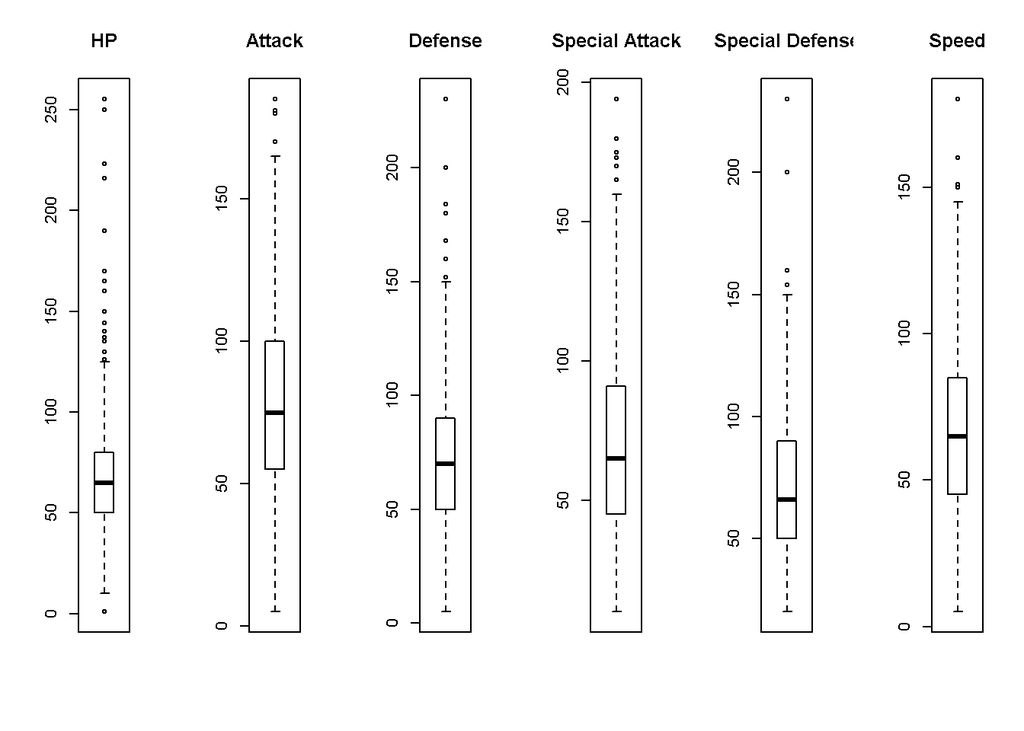

A continuació, es presenta un quadre resum amb el TOP 6 de pokémons més destacats per stat:

| hp | Blissey (255) | Chansey (250) | Guzzlord (223) | Zygarde (216) | Wobbufet (190) | Wailord (170) |
| --- | --- | --- | --- | --- | --- | --- |
| atac | Heracross (185) | Kartana (181) | Groudon (180) | Rayquaza (180) | Garchomp (170) | Rampardos (165) |
| defensa | Steelix (230) | Shuckle (230) | Aggron (230) | Regirock (200) | Avalugg (184) | Slowbro (180) |
| atac especial | Mewtwo (194) | Kyogre (194) | Rayquaza (180) | Alakazam (175) | Gengar (170) | Kyurem (170) |
| defensa especial | Shuckle (230) | Regice (200) | Kyogre (160) | Lugia (154) | Ho-Oh (154) | Florges (154) |
| velocitat | Deoxys (180) | Ninjask (160) | Phermosa (151) | Alakazam (150) | Electrode (150) | Aerodactyl (150) |

### 3.2.2 Alçada i pes

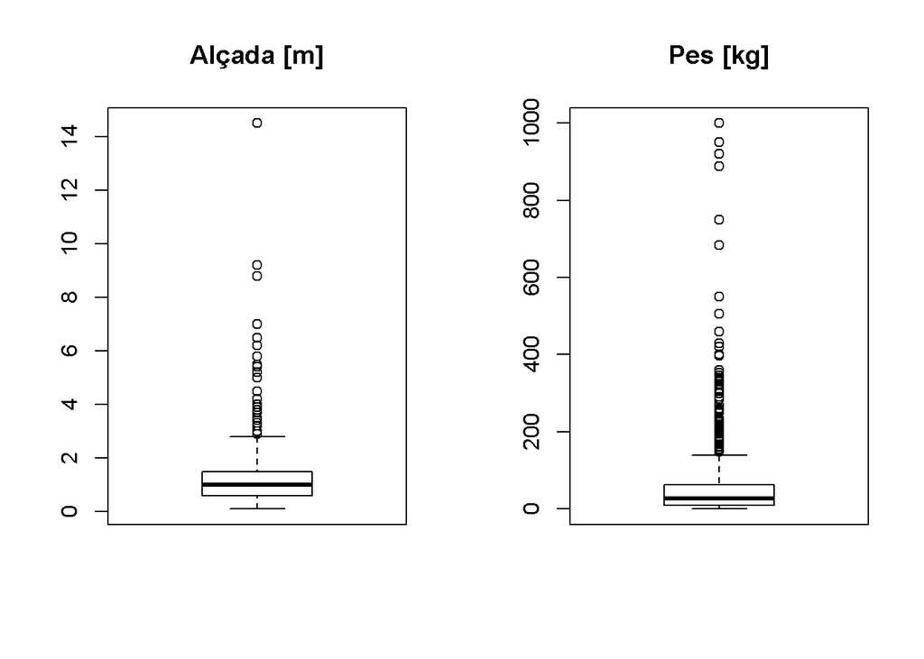

- El 50% dels pokémons té una alçada compresa entre 0.6 i 1.5 m. El pokémon més alt és: Wailord (14.5 kg)
- El 50% dels pokémons té un pes compres entre 9 i 63 kg. Els pokémons amb més pes són: Cosmoem i Celesteela (999.9 kg)

### 3.2.3 Felicitat

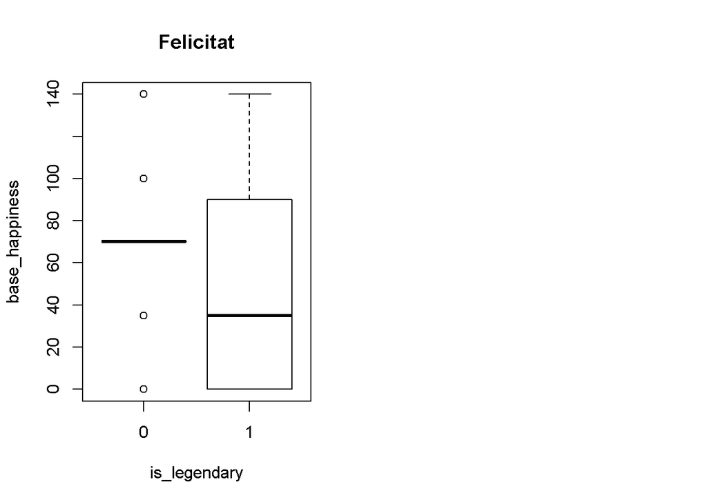

[figure not shown]

Veiem que generalment els pokémons llegendaris tenen una estadística de felicitat més baixa que els pokémons que no ho són. De fet, la mediana en la felicitat dels pokémons llegendaris es troba a la meitat que els pokémons comuns. Per tant, podem dir que els pokémons comuns són generalment dues vegades més feliços que els pokémons llegendaris. A més a més, els pokémons que tenen una felicitat registrada més alta són de tipus fada, normal o psíquic.

# 4 Pregunta

## 4.1 Selecció dels grups de dades a analitzar

En les següents seccions es realitzaran els següents anàlisis:

**- Anàlisis de regressió**. Estudiarem possibles correlacions entre els stats dels pokémon i les seves característiques físiques: alçada i pes. Veurem si existeixen dependències en funció de si els pokémon són llegendaris o no. Les variables que necessitarem seran: height_m, weight_kg, hp, attack, defense, sp_attack, sp_defense,speed i is_legendary.

**- Anàlisis de correlació (Heatmap)**. Estudiarem l’efectivitat entre tipus de pokémon. Per fer-ho, necessitarem els 18 atributs que contenen els valors d’efectivitat i també la variable type1 per cada pokémon.

**- Construcció d’un model random forest**. Estudiarem si hi alguna possibilitat de predir si un pokémon és llegendari o no construïnt un model random forest. El model utilitzara els stats, tipus i si es llegendari o no el pokémon.

## 4.2 Normalitat i homogeneïtat de la variància en les dades

### 4.2.1 Test de Normalitat

En estadística existeix el **teorema central del límit** que s’aplica a la distribució de la mitjana de la mostra d’un conjunt de dades. La mitjana d’una mostra de qualsevol conjunt de dades és cada vegada més normal a mesura que augmenta la quantitat d’observacions. Així, podríem assumir que a mesura que augmenta el tamany de la nostra mostra aquesta és cada vegada més normal.

A continuació, assumirem que la hipòtesis del teorema central del límit es compleix pel nostre conjunt de dades ja que comptem amb 800 observacions i es considera una mostra suficientment gran, tot i això, també **aplicarem el test de Shapiro-Wilk ja que es tracta d’una prova més robusta de normalitat**. Bàsicament realitzarem l’anàlisis sobre dos grups, aquells pokémons que són llegendaris i aquells que no ho són.

```
##
##  Shapiro-Wilk normality test
##
## data:  df_net$hp[df_net$is_legendary == 0]
## W = 0.89226, p-value < 2.2e-16
```

```
##
##  Shapiro-Wilk normality test
##
## data:  df_net$hp[df_net$is_legendary == 1]
## W = 0.83308, p-value = 2.031e-07
```

```
##
##  Shapiro-Wilk normality test
##
## data:  df_net$attack[df_net$is_legendary == 0]
## W = 0.97872, p-value = 7.992e-09
```

```
##
##  Shapiro-Wilk normality test
##
## data:  df_net$attack[df_net$is_legendary == 1]
## W = 0.97599, p-value = 0.1979
```

```
##
##  Shapiro-Wilk normality test
##
## data:  df_net$defense[df_net$is_legendary == 0]
## W = 0.9261, p-value < 2.2e-16
```

```
##
##  Shapiro-Wilk normality test
##
## data:  df_net$defense[df_net$is_legendary == 1]
## W = 0.95512, p-value = 0.01357
```

```
##
##  Shapiro-Wilk normality test
##
## data:  df_net$sp_attack[df_net$is_legendary == 0]
## W = 0.96337, p-value = 1.496e-12
```

```
##
##  Shapiro-Wilk normality test
##
## data:  df_net$sp_attack[df_net$is_legendary == 1]
## W = 0.98703, p-value = 0.688
```

```
##
##  Shapiro-Wilk normality test
##
## data:  df_net$sp_defense[df_net$is_legendary == 0]
## W = 0.95668, p-value = 7.431e-14
```

```
##
##  Shapiro-Wilk normality test
##
## data:  df_net$sp_defense[df_net$is_legendary == 1]
## W = 0.95976, p-value = 0.02428
```

```
##
##  Shapiro-Wilk normality test
##
## data:  df_net$speed[df_net$is_legendary == 0]
## W = 0.97946, p-value = 1.321e-08
```

```
##
##  Shapiro-Wilk normality test
##
## data:  df_net$speed[df_net$is_legendary == 1]
## W = 0.95194, p-value = 0.009178
```

A continuació, es mostra una taula amb els resultats de shapiro test.

[output not shown]

### 4.2.2 Test de Variància

```r
#Apliquem el test de Fligner

fligner.test(hp ~ is_legendary, data=df_net)
```

```
##
##  Fligner-Killeen test of homogeneity of variances
##
## data:  hp by is_legendary
## Fligner-Killeen:med chi-squared = 0.14252, df = 1, p-value =
## 0.7058
```

```r
fligner.test(attack ~ is_legendary, data=df_net)
```

```
##
##  Fligner-Killeen test of homogeneity of variances
##
## data:  attack by is_legendary
## Fligner-Killeen:med chi-squared = 0.030517, df = 1, p-value =
## 0.8613
```

```r
fligner.test(defense ~ is_legendary, data=df_net)
```

```
##
##  Fligner-Killeen test of homogeneity of variances
##
## data:  defense by is_legendary
## Fligner-Killeen:med chi-squared = 2.0312, df = 1, p-value = 0.1541
```

```r
fligner.test(sp_attack ~ is_legendary, data=df_net)
```

```
##
##  Fligner-Killeen test of homogeneity of variances
##
## data:  sp_attack by is_legendary
## Fligner-Killeen:med chi-squared = 3.3808, df = 1, p-value =
## 0.06596
```

```r
fligner.test(sp_defense ~ is_legendary, data=df_net)
```

```
##
##  Fligner-Killeen test of homogeneity of variances
##
## data:  sp_defense by is_legendary
## Fligner-Killeen:med chi-squared = 0.00024498, df = 1, p-value =
## 0.9875
```

```r
fligner.test(speed ~ is_legendary, data=df_net)
```

```
##
##  Fligner-Killeen test of homogeneity of variances
##
## data:  speed by is_legendary
## Fligner-Killeen:med chi-squared = 5.3923, df = 1, p-value =
## 0.02023
```

## 4.3 Correlació pes i alçada amb estadístiques base (Anàlisi de Regressió)

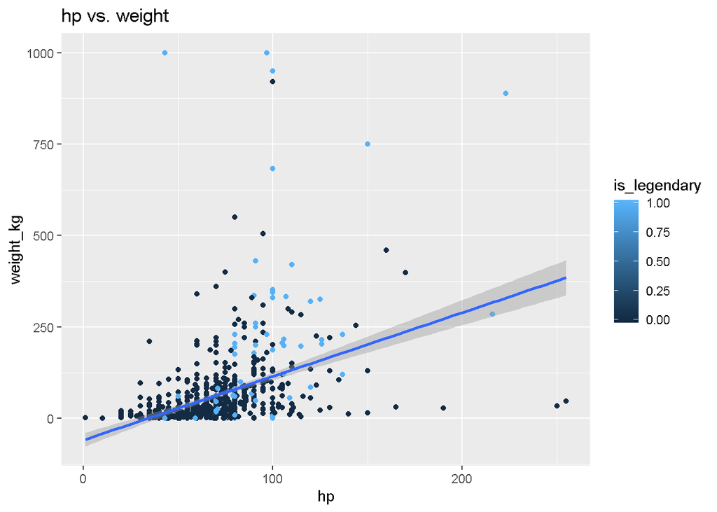

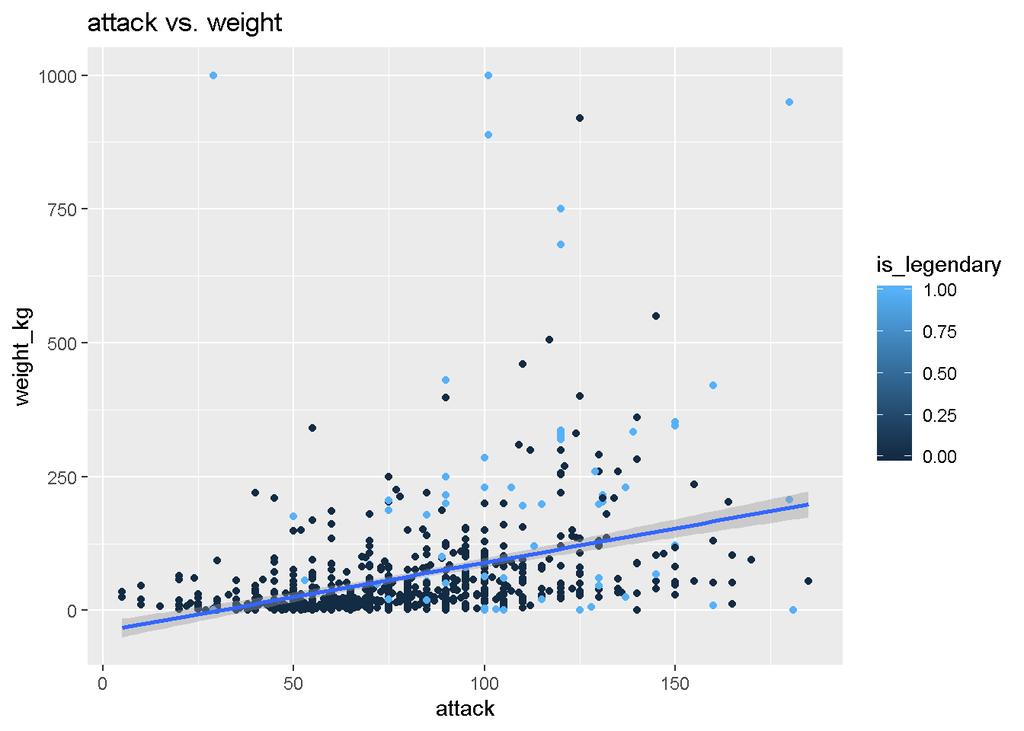

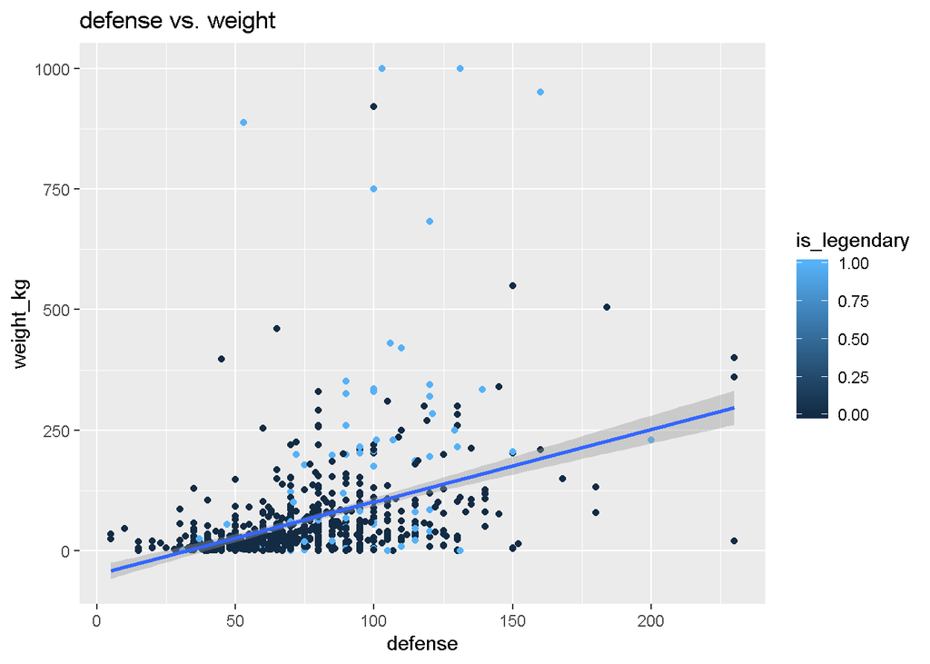

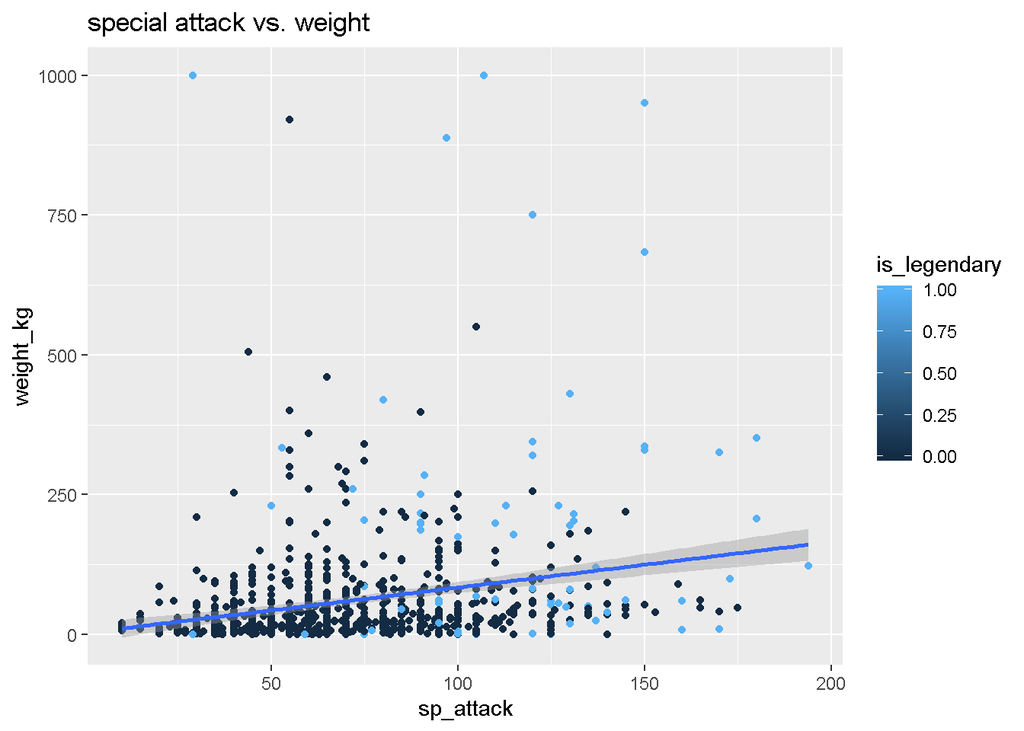

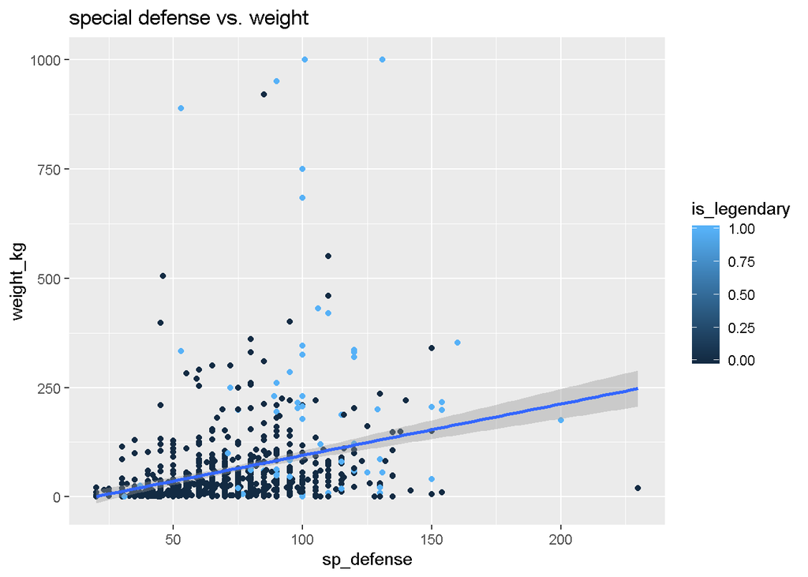

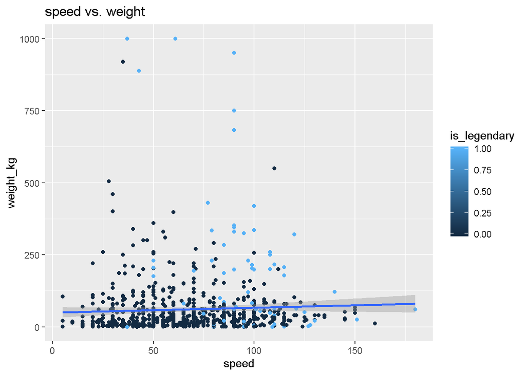

Dels plots anteriors podem veure que els stats atack, defensa, atac especial i defensa especial generalment augmenten amb el pes. Podem veure que no hi ha el mateix comportament amb la velocitat on la relació entre ambdós atributs no és tant forta.

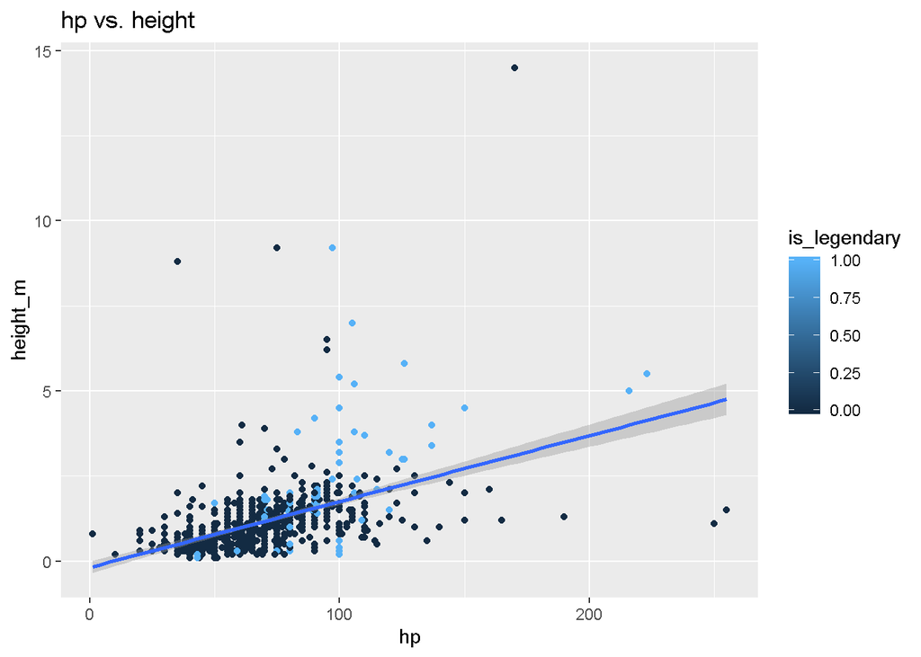

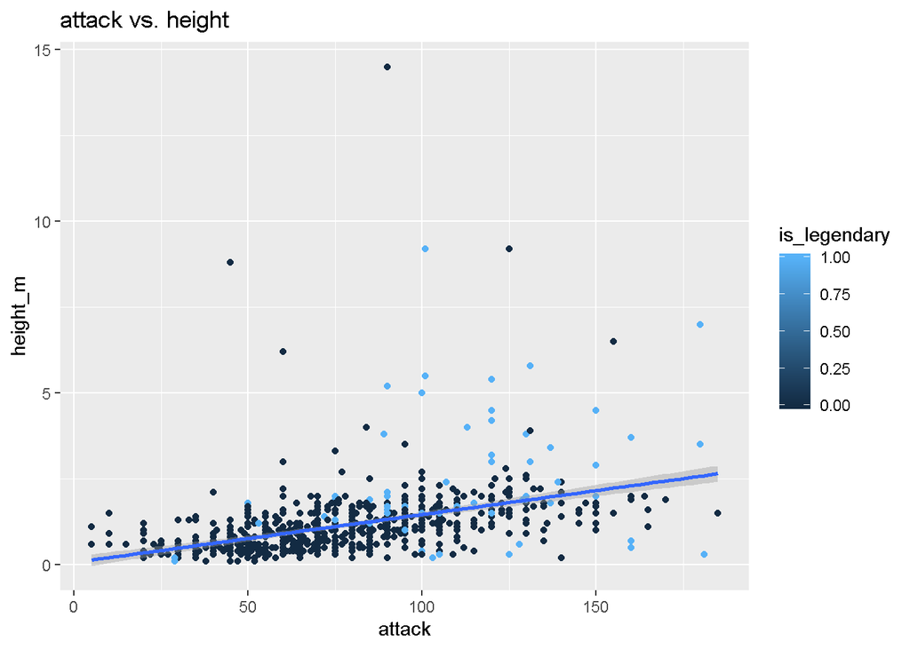

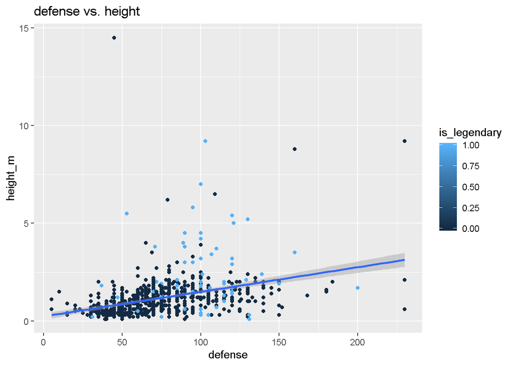

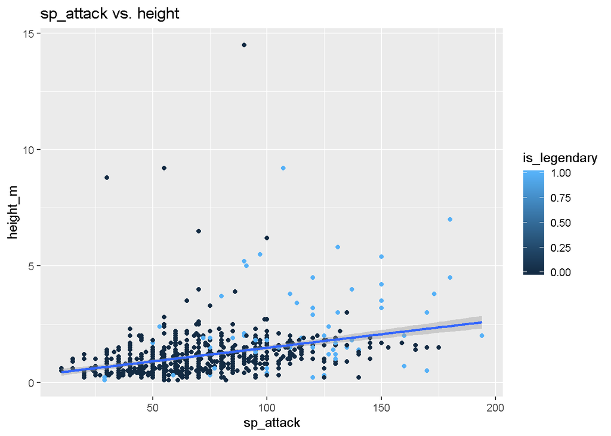

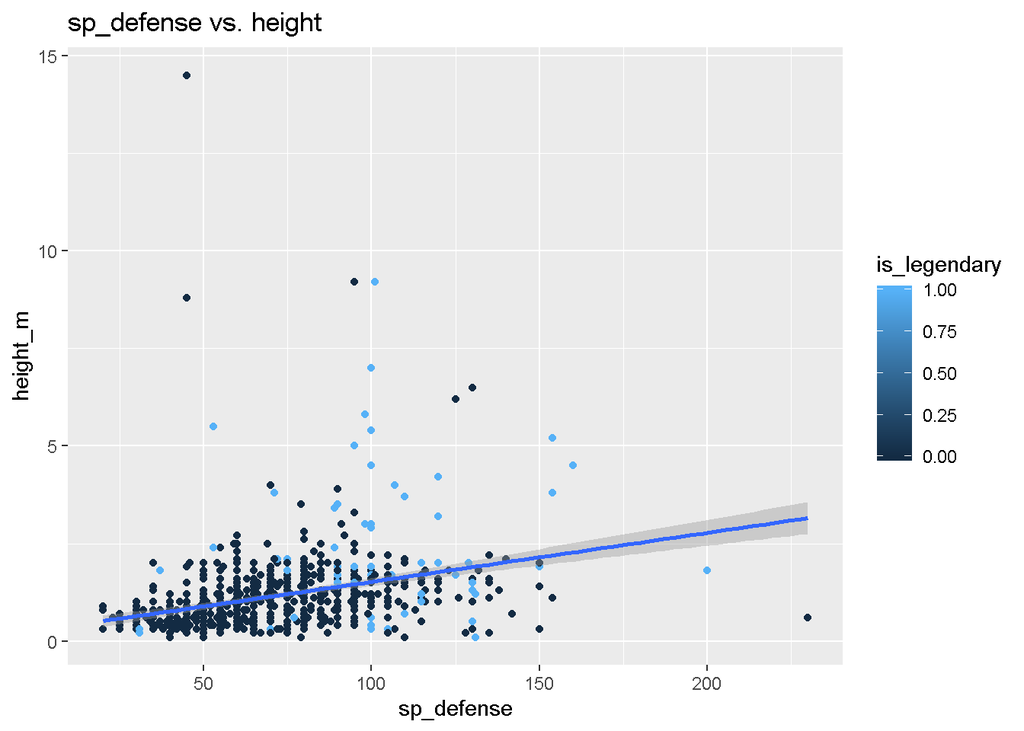

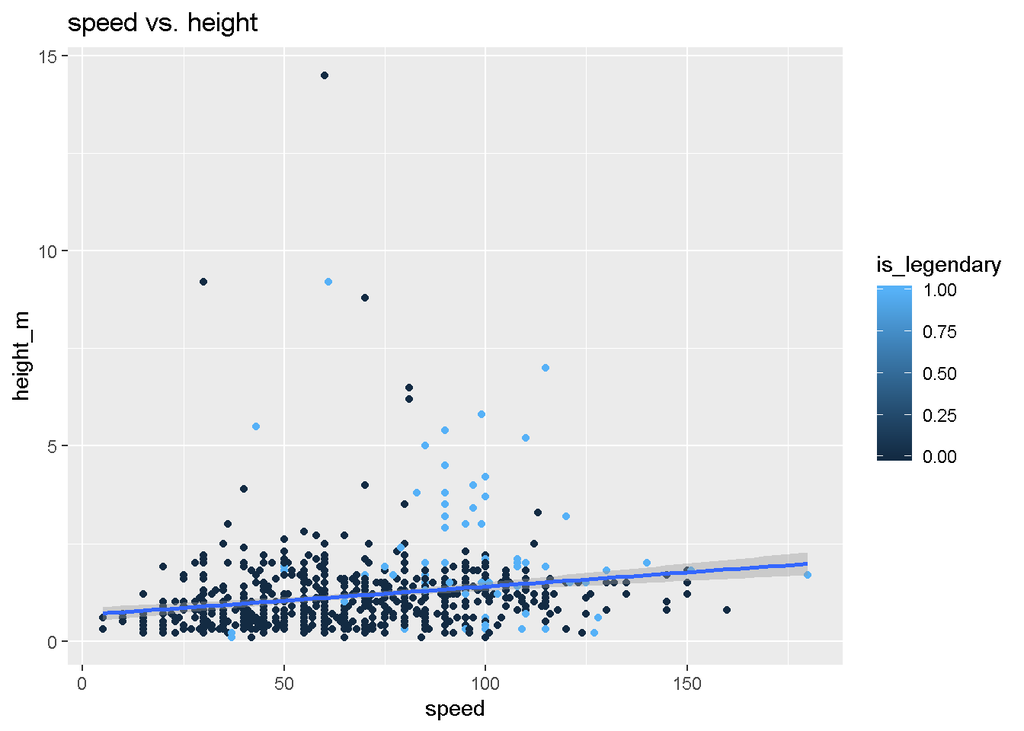

Podem veure que tots els stats augmenten generalment amb l’alçada del pokemon. De totes maneres, la velocitat és un altra cop la que mostra una relació menys forta amb l’alçada tot i que no és tant significatiu com en el cas del pes.

També podem observar com en general, els pokémons que són llegendaris tenen una alçada i pes major que els pokémons comuns.

## 4.4 Anàlisi de l’efectivitat de tipus de pokémon (Heatmap)

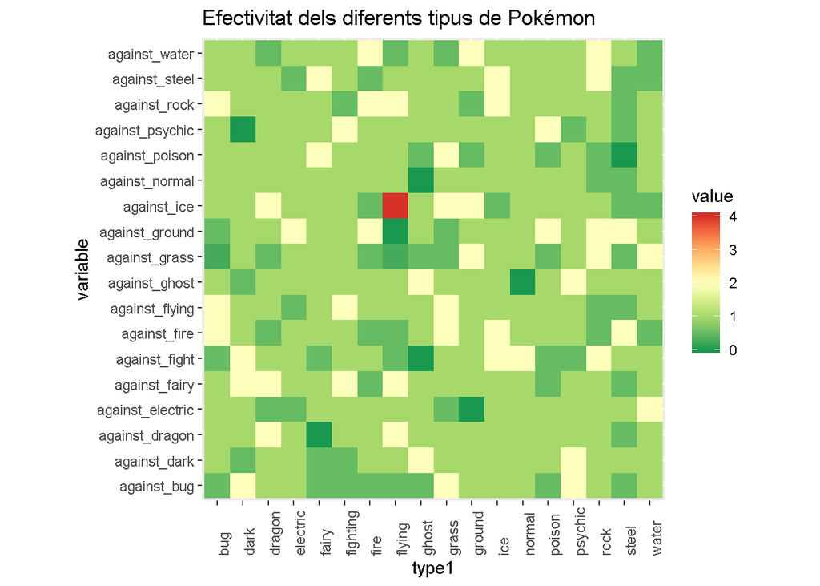

El heatmap està organitzat per una escala de colors de 0 (verd) a vermell (4) amb una transició suau pel color groc.

## 4.5 Classificador de Pokémon Llegendaris (Random Forest)

En aquesta secció, construirem un model supervisat (Random Forest) per identificar si és possible Classificar un Pokémon. En aquest sentit, el que volem saber és quins són els atributs (si n’hi ha) reben una major importància a l’hora de determinar si un Pokémon es pot considerar llegendari o no.

```r
require(caTools)
#Creem el randomforest amb 500 arbres
rf <- randomForest(is_legendary ~ .,data=train,importance=TRUE)
rf
```

```
##
## Call:
##  randomForest(formula = is_legendary ~ ., data = train, importance = TRUE)
##                Type of random forest: classification
##                      Number of trees: 500
## No. of variables tried at each split: 6
##
##         OOB estimate of  error rate: 11.02%
## Confusion matrix:
##    0  1 class.error
## 0 62  5  0.07462687
## 1  8 43  0.15686275
```

```
##    pred
##      0  1
##   0 32  1
##   1  2 17
```

### 4.5.1 Importància dels atributs

Gràcies a la naturalesa dels arbres de decisió, aquests són capaços de seleccionar quins atributs són més importants al realitzar una classificació. Aquest fet, ens ajudarà a decidir quins atributs són més importants per decidir que un Pokémon és llegendari o no ho és.

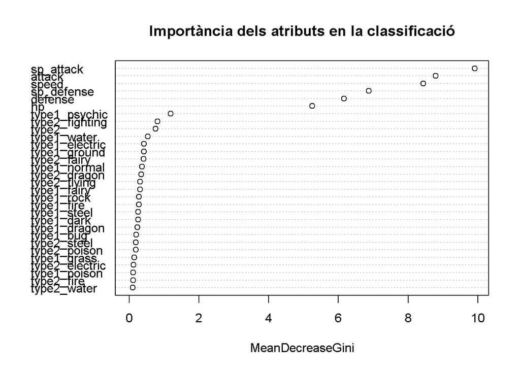

Veiem que l’atribut que més destaca per determinar si un pokémon és llegendari és l’atac especial. Podem veure com el tipus del pokémon no és rellevant en la classificació de llegendari, tot i això, veiem que el tipus psíquic és el que més destaca entre ells.

# 5 Conclusions

**- Quina correlació existeix entre l’alçada i el pes d’un pokemon amb les seves estadístiques base?**

S’ha vist que generalment els pokémons amb més alçada i pes tenen uns stats més alts excepte per la velocitat en que la correlació no és tant forta com amb la resta d’atributs.

**- Quins Pokémons tenen els stats més alts?**

A través dels outliers hem pogut determinar quins són aquells pokémons que tenen els stats més alts (veure taula creada)

**- Quina efectivitat hi ha entre tipus de Pokémons?**

S’ha creat un heatmap per comparar quin és el dany que inflingeix un pokémon sobre un altre tipus de pokémon. S’ha pogut veure que el tipus de gel és el que inflingeix més dany sobre el tipus volador. Tot i això, aquest anàlisis s’hauria de complementar amb el l’anàlisis del segon tipus. S’ha decidit analitzar únicament el tipus 1 ja que més del 50% dels pokémons només tenen un tipus.

**- Quins pokémons són més feliços?**

Hem vist quins són els pokémons que tenen un stat de felicitat més elevat, també s’ha pogut veure que aquests pokémons són de tipus fada, normal i psíquic.

# 6 Contribucions al treball

| Contribucions al treball | Contribucions al treball Firma1 | Contribucions al treball Firma2 |
| --- | --- | --- |
| Pregunta 1 | XPV | JSD |
| Pregunta 2 | XPV | JSD |
| Pregunta 3 | XPV | JSD |
| Pregunta 4 | XPV | JSD |
| Conclusions | XPV | JSD |

.